# Project Description

```
 Processing Fold 1/4
Tuning KNN for Fold 1
  > Fold 1 Test ROC AUC: 0.5947
  > Best Params Found: {'metric': 'minkowski', 'n_neighbors': 7, 'weights': 'distance'}

 Processing Fold 2/4
Tuning KNN for Fold 2
  > Fold 2 Test ROC AUC: 0.4926
  > Best Params Found: {'metric': 'minkowski', 'n_neighbors': 3, 'weights': 'distance'}

 Processing Fold 3/4
Tuning KNN for Fold 3
  > Fold 3 Test ROC AUC: 0.5503
  > Best Params Found: {'metric': 'manhattan', 'n_neighbors': 6, 'weights': 'uniform'}

 Processing Fold 4/4
Tuning KNN for Fold 4
  > Fold 4 Test ROC AUC: 0.4526
  > Best Params Found: {'metric': 'manhattan', 'n_neighbors': 4, 'weights': 'distance'}
              precision    recall  f1-score   support

        DOWN       0.51      0.50      0.51       303
          UP       0.48      0.49      0.49       285

    accuracy                           0.50       588
   macro avg       0.50      0.50      0.50       588
weighted avg       0.50      0.50      0.50       588

      ROC AUC  Accuracy  Best k Best Weights Best Metric
Fold
1      0.5947    0.5510       7     distance   minkowski
2      0.4926    0.5102       3     distance   minkowski
3      0.5503    0.4898       6      uniform   manhattan
4      0.4526    0.4354       4     distance   manhattan
Aggregated Out-of-Sample ROC AUC: 0.5106
Mean of Fold ROC AUCs:            0.5225
Std Dev of Fold ROC AUCs:         0.0626
```

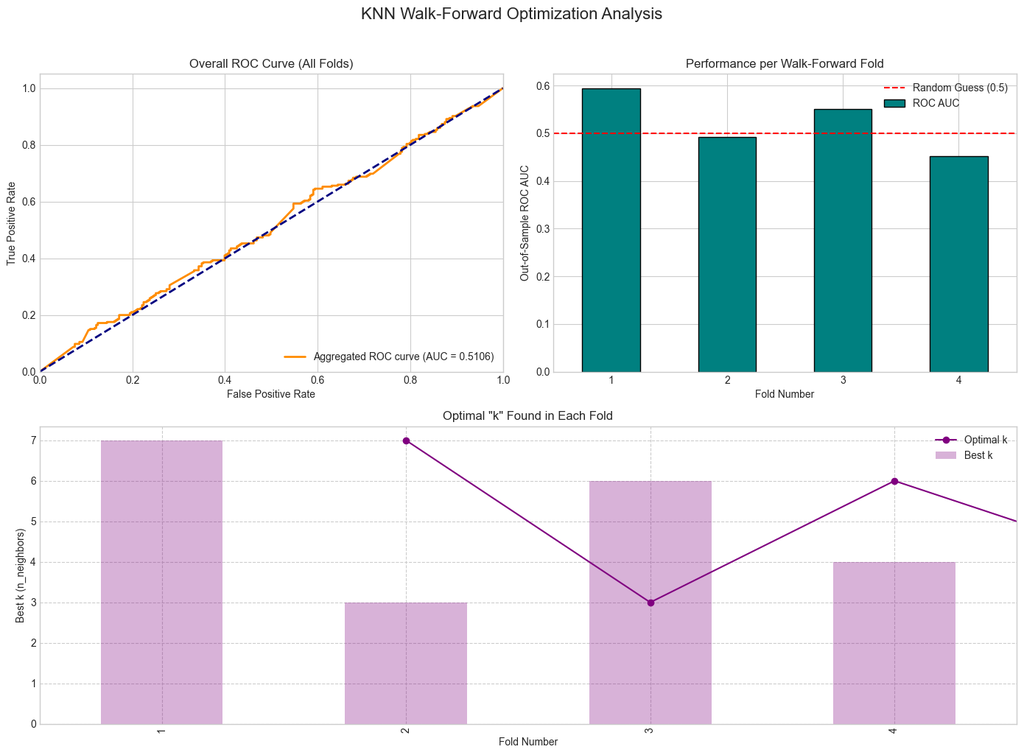

```python
import pandas as pd
import numpy as np
import warnings
from sklearn.model_selection import TimeSeriesSplit, GridSearchCV
from sklearn.preprocessing import StandardScaler
from sklearn.neighbors import KNeighborsClassifier
from sklearn.metrics import accuracy_score, roc_auc_score, roc_curve, classification_report
import matplotlib.pyplot as plt

warnings.filterwarnings('ignore')

# --- 1. Define Model and Expanded Hyperparameter Grid ---
knn_model = KNeighborsClassifier()
param_grid = {
    'n_neighbors': range(1, 10),
    'weights': ['uniform', 'distance'],
    'metric': ['minkowski', 'manhattan']
}


# --- 2. Set up and Execute Walk-Forward Optimization ---
n_splits = 4
tscv = TimeSeriesSplit(n_splits=n_splits, test_size=147)

fold_results = []
all_y_test_agg = []
all_y_pred_proba_agg = []

for fold, (train_index, test_index) in enumerate(tscv.split(X)):
    fold_num = fold + 1
    print(f"\n Processing Fold {fold_num}/{n_splits}")

    X_train, X_test = X.iloc[train_index], X.iloc[test_index]
    y_train, y_test = y.iloc[train_index], y.iloc[test_index]

    scaler = StandardScaler()
    X_train_scaled = scaler.fit_transform(X_train)
    X_test_scaled = scaler.transform(X_test)

    inner_tscv = TimeSeriesSplit(n_splits=3)

    print(f"Tuning KNN for Fold {fold_num}")
    grid_search = GridSearchCV(
        estimator=knn_model, param_grid=param_grid, cv=inner_tscv, scoring='roc_auc', n_jobs=-1
    )
    grid_search.fit(X_train_scaled, y_train)

    best_params = grid_search.best_params_
    best_knn_for_fold = grid_search.best_estimator_

    y_pred_proba = best_knn_for_fold.predict_proba(X_test_scaled)[:, 1]

    fold_results.append({
        'Fold': fold_num,
        'ROC AUC': roc_auc_score(y_test, y_pred_proba),
        'Accuracy': accuracy_score(y_test, (y_pred_proba > 0.5).astype(int)),
        'Best k': best_params['n_neighbors'],
        'Best Weights': best_params['weights'],
        'Best Metric': best_params['metric']
    })

    all_y_test_agg.extend(y_test)
    all_y_pred_proba_agg.extend(y_pred_proba)

    print(f"  > Fold {fold_num} Test ROC AUC: {fold_results[-1]['ROC AUC']:.4f}")
    print(f"  > Best Params Found: {best_params}")

# --- 3. Aggregate and Display Final Results ---

# A) Overall Performance Metrics for all folds
all_y_pred_agg = (np.array(all_y_pred_proba_agg) > 0.5).astype(int)
print(classification_report(all_y_test_agg, all_y_pred_agg, target_names=['DOWN', 'UP']))

# B) Fold-by-Fold Performance Breakdown
results_df = pd.DataFrame(fold_results).set_index('Fold')
print(results_df.round(4))

# C) Final Summary Statistics
mean_roc_auc_agg = roc_auc_score(all_y_test_agg, all_y_pred_proba_agg)
print(f"Aggregated Out-of-Sample ROC AUC: {mean_roc_auc_agg:.4f}")
print(f"Mean of Fold ROC AUCs:            {results_df['ROC AUC'].mean():.4f}")
print(f"Std Dev of Fold ROC AUCs:         {results_df['ROC AUC'].std():.4f}")


# --- 4. Visualize the Results ---
plt.style.use('seaborn-v0_8-whitegrid')
fig = plt.figure(figsize=(14, 10))

# --- Plot 1: ROC Curve for Aggregated Predictions ---
ax1 = plt.subplot2grid((2, 2), (0, 0))
fpr, tpr, _ = roc_curve(all_y_test_agg, all_y_pred_proba_agg)
ax1.plot(fpr, tpr, color='darkorange', lw=2, label=f'Aggregated ROC curve (AUC = {mean_roc_auc_agg:.4f})')
ax1.plot([0, 1], [0, 1], color='navy', lw=2, linestyle='--')
ax1.set_xlim([0.0, 1.0])
ax1.set_ylim([0.0, 1.05])
ax1.set_xlabel('False Positive Rate')
ax1.set_ylabel('True Positive Rate')
ax1.set_title('Overall ROC Curve (All Folds)')
ax1.legend(loc="lower right")
ax1.grid(True)

# --- Plot 2: ROC AUC Score per Fold ---
ax2 = plt.subplot2grid((2, 2), (0, 1))
results_df['ROC AUC'].plot(kind='bar', ax=ax2, color='teal', edgecolor='black')
ax2.axhline(0.5, ls='--', color='red', label='Random Guess (0.5)')
ax2.set_title('Performance per Walk-Forward Fold')
ax2.set_xlabel('Fold Number')
ax2.set_ylabel('Out-of-Sample ROC AUC')
ax2.legend()
ax2.tick_params(axis='x', rotation=0)

# --- Plot 3: Best 'k' Found per Fold ---
ax3 = plt.subplot2grid((2, 2), (1, 0), colspan=2)
results_df['Best k'].plot(kind='line', ax=ax3, marker='o', color='purple', label='Optimal k')
results_df['Best k'].plot(kind='bar', ax=ax3, color='purple', alpha=0.3)
ax3.set_title('Optimal "k" Found in Each Fold')
ax3.set_xlabel('Fold Number')
ax3.set_ylabel('Best k (n_neighbors)')
ax3.legend()
ax3.grid(True, which='both', linestyle='--')

fig.suptitle('KNN Walk-Forward Optimization Analysis', fontsize=16, y=1.02)
plt.tight_layout()
plt.show()
```

**Results and Analysis** To conduct a comprehensive evaluation of the K-Nearest Neighbors (KNN) model, I implemented a walk-forward optimization framework with enhanced hyperparameter tuning. In each of the four sequential folds, the model's key parameters: n_neighbors (k), weights, and distance metrics were optimized on the training data before performance was measured on the subsequent unseen test set. This robust methodology provides a realistic assessment of the model's predictive power and its stability over time.

# Conclusion - Everyone

This project aimed to predict the percentage change in WTI crude oil futures prices two minutes following the Energy Information Agency's (EIA) Weekly Petroleum Status Report (WPSR), leveraging various machine learning techniques. The models implemented included Linear Regression (with Lasso), Random Forest, XGBoost, Deep Neural Network (DNN), and K-Nearest Neighbors (KNN).

**Key Findings & Model Performance:**

**Overall Insights & Comparative Analysis:**

**Limitations and Future Directions:**

The project successfully demonstrated that machine learning models can extract some predictive signal from pre-release market data and EIA report statistics. However, the predictive power varied across models. Future work could explore:

- More sophisticated feature engineering, particularly for capturing nuanced pre-release market dynamics.
- Advanced time-series models (e.g., LSTMs, Transformers) specifically designed for sequential data, perhaps with a richer set of historical price/volume features.
- Ensemble techniques that combine the predictions of the best-performing individual models.
- Further investigation into the DNN architecture, feature scaling, and optimization to potentially unlock better performance.
- Incorporating transaction costs to assess the real-world viability of strategies based on these predictions.

In conclusion, while no single model emerged as a definitive solution for highly accurate, consistent predictions, the Random Forest and Lasso models showed considerable promise for regression, and the KNN provided evidence of a slight directional edge. The project underscores the complexity of financial market prediction and the necessity of robust methodology, appropriate feature engineering, and careful model selection and validation.